# MOOC Dataset

# Intruduction

The dropout rate for distance learning courses is very high and the success rate for students is low. Success here will be defined when the student receives the course certificate. Variables such as sex, education level, number of interactions with the platform and country of origin will be considered.

# Data

The data used were made available by the University of Havard and refer to a set of student results from the year 2013. The database can be accessed at the following address https://dataverse.harvard.edu/dataverse/mxhx

# Metodologies

Logistic Regression

Desicion Tree

Random Forest

Gradient Boosting

XGboost

Deep Learning (sequential model)

We will first load the necessary packages.

```r
require(data.table)
require(ggplot2)
require(verification)
require(Hmisc)
require(keras)
require(tidyverse)
require(ROCR)
require(rpart)
require(rpart.plot)
require(randomForest)
require(gbm)
require(xgboost)
require(Matrix)
```

The data set was made available in Rdata format and can be loaded using the following command. To facilitate data manipulation, the table will be converted to data.table format.

```r
load("C:/Users/EricaCastilho/Dropbox/Recrutamentos/Github/MOOC Dataset/MoocData.RData")
dados_estudantes<-data.table(x)
rm(x)

# Fiz seed
set.seed(3)

# Convert grades in numeric
dados_estudantes$grade<-as.numeric(dados_estudantes$grade)

# Convert cerfified in factor
dados_estudantes$certified<-factor(dados_estudantes$certified)
```

Now we are going to filter in the database only those variables that are possible features of our model: year of birth, sex, grade in the course, number of events in the course, number of active days, degree of education of the student, number of times he attended videos, number of chapters visited, number of forum posts and student country.

```r
dados_filtrados<-dados_estudantes[,c('certified','YoB','gender','grade','nevents','ndays_act','LoE_DI','nplay_video','nchapters','nforum_posts','final_cc_cname_DI')]
```

The database presents a large number of missing data. Therefore, we will use an imputation method to solve this problem. The Hmisc package will be used here. For the numerical variables we will use the mean as an imputation function and for the categorical variables the package used the Fisher’s optimum scoring method.

```r
#Quantitative variables
dados_filtrados$grade <- with(dados_filtrados, impute(grade, mean))
dados_filtrados$nevents <- with(dados_filtrados, impute(nevents, mean))
dados_filtrados$ndays_act <- with(dados_filtrados, impute(ndays_act, mean))
dados_filtrados$nplay_video <- with(dados_filtrados, impute(nplay_video, mean))
dados_filtrados$nchapters <- with(dados_filtrados, impute(nchapters, mean))


# Quallitative variables
dados_filtrados$YoB <- with(dados_filtrados, impute(YoB))
dados_filtrados$gender <- with(dados_filtrados, impute(gender))
dados_filtrados$LoE_DI <- with(dados_filtrados, impute(LoE_DI))

# Transform qualitative into factors
dados_filtrados$YoB<-factor(dados_filtrados$YoB)
dados_filtrados$gender<-factor(dados_filtrados$gender)
dados_filtrados$LoE_DI <- factor(dados_filtrados$LoE_DI)
dados_filtrados$final_cc_cname_DI<-factor(dados_filtrados$final_cc_cname_DI)
```

In order to fit and evaluate the models we will divide the base into a set of tests (20%) and training (80%).

```r
# index train

train<-sample(c(0,1),nrow(dados_estudantes),prob=c(0.2,0.8),replace=T)
```

# Logistic model

The first model we fit is the simplest one, the logistic model. We will then estimate the values for the test data , calculate the accuracy of the model and make its ROC curve

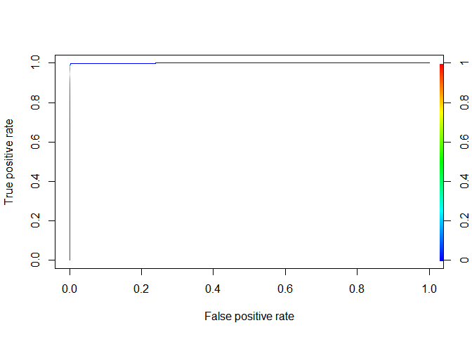

```r
## Logistic Model
full.logit<-glm(data =dados_filtrados[train==1,],certified~.,family = binomial(link=logit))


full.logit_predict<-predict(full.logit,type = "response")

## Predictions
dados_test<-dados_filtrados[train==0]
dados_test$predito_logistic_prob<-predict(full.logit,dados_test[,-c('certified')],type = "response")
dados_test$predito_logisct<-ifelse(dados_test$predito_logistic_prob>0.5,1,0)

## Accuracy
conf_matrix<-table(dados_test$predito_logisct,dados_test$certified)
precisao_logistica<-sum(diag(conf_matrix))/sum(conf_matrix)


## ROC curve
pred <- prediction(full.logit_predict,dados_filtrados[train==1,certified])
perf <- performance(pred,"tpr","fpr")
plot(perf,colorize=TRUE)
```

The accuracy for this model turns out to be 99.8406%.